# Problem3.6

### Importing and Setting up the Data

```r
UNLifeExpectancy <- read.csv(file.path(str_remove(getwd(), "/Class Notes"), "/Book Data/UNLifeExpectancy.csv"))
view(UNLifeExpectancy)
UNLifeExpectancy <- UNLifeExpectancy %>%
  mutate(lnHEALTH = log(PRIVATEHEALTH))
```

### Generating the Regression Model

```r
LifeExpReg <- lm(LIFEEXP ~ FERTILITY+PUBLICEDUCATION+lnHEALTH, data = UNLifeExpectancy)
```

### Summarizing the Regression Model

```r
summary(LifeExpReg)
```

```
##
## Call:
## lm(formula = LIFEEXP ~ FERTILITY + PUBLICEDUCATION + lnHEALTH,
##     data = UNLifeExpectancy)
##
## Residuals:
##     Min      1Q  Median      3Q     Max
## -23.013  -4.090   1.218   4.597  12.589
##
## Coefficients:
##                 Estimate Std. Error t value Pr(>|t|)
## (Intercept)      85.6264     2.0033  42.742   <2e-16 ***
## FERTILITY        -5.3993     0.3308 -16.324   <2e-16 ***
## PUBLICEDUCATION  -0.1846     0.2685  -0.688    0.493
## lnHEALTH         -1.0296     0.9431  -1.092    0.277
## ---
## Signif. codes:  0 '***' 0.001 '**' 0.01 '*' 0.05 '.' 0.1 ' ' 1
##
## Residual standard error: 6.645 on 148 degrees of freedom
##   (33 observations deleted due to missingness)
## Multiple R-squared:  0.645,  Adjusted R-squared:  0.6378
## F-statistic: 89.64 on 3 and 148 DF,  p-value: < 2.2e-16
```

$$\widehat{LifeExp}=85.6264-5.3993x_{Fertility}-0.1846x_{PublicEducation}-1.0296x_{logHealth}$$

### Problems

#### a.)

Holding all other explanatory variables constant. For every 1% increase of a country’s GDP being spent on public education, we can expect the average life expectancy of that country to decrease by ~0.2 years.

#### b.)

Holding all other explanatory variables constant. For every factor of $e$ increase in the country’s health expenditures, we can expect the average life expectancy of that country to decrease by ~1 year.

#### c.)

$$H_O:\beta_{PublicEducation}=0 \newline
H_A:\beta_{PublicEducation}\not=0$$
If the minimum p-value from the 2-sided t-test is greater than $\alpha$=5%, then we fail to reject $H_O$.
However, if the minimum p-value from the 2-sided t-test is less than $\alpha$=5%, then we reject $H_O$
From the summary of the LifeExpReg, we can see that the p-value from the 2-sided t-test for Public Education was 49.3%. Since our p-value of 49.3% is greater than $\alpha$=5%, we fail to reject the null hypothesis. Therefore, there is no statistically significant evidence that $\beta_{PublicEducation}$ is different from 0.

Here is the scatter plot of Public Education Expenditure compared to Life Expectancy:

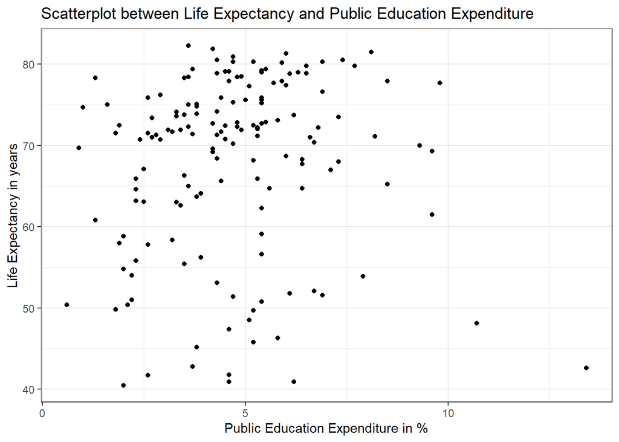

### 3.3

```r
Dat <- matrix(c(-1, 2, 4, 6,
                0, 0, 1, 1,
                0, 1, 5, 8),
              byrow = TRUE, nrow=3, ncol=4,
              dimnames=list(c("xi1", "xi2", "yi"), c(1:4)))
b <- c(0.15, 0.692, 2.88)
H <- matrix(c(0.53846, -0.07692, -0.15385,
              -0.07692, 0.15385, -0.69231,
              -0.15385, -0.69231, 4.11538),
            byrow=TRUE, nrow=3, ncol=3)
s <- 1.373
```

#### a.)

```r
y <- Dat[3,]
X <- rbind(rep(1, times=4),Dat[1:2,])
```

#### b.)

```r
t(X) %*% b
```

```
##     [,1]
## 1 -0.542
## 2  1.534
## 3  5.798
## 4  7.182
```

$\hat{y}_3=5.798$

#### c.)

```r
H
```

```
##          [,1]     [,2]     [,3]
## [1,]  0.53846 -0.07692 -0.15385
## [2,] -0.07692  0.15385 -0.69231
## [3,] -0.15385 -0.69231  4.11538
```

```r
s * sqrt(4.11538)
```

```
## [1] 2.785323
```

$se(b_2)=2.785323$